# R Assessment

2023-01-29

### Table

#### Correlation Between Team Cohesion, Task Interdependence, and Team Performance

[output not shown]

### Regression Plots

#### Linear Regression Plots Measuring how Team Cohesion and Task Interdependence Affect Team Performance

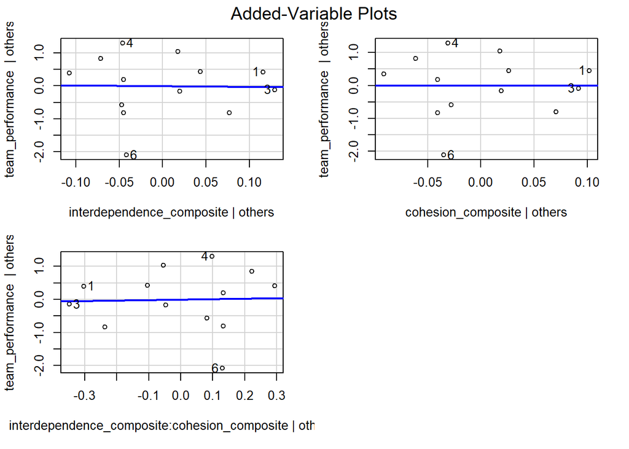

#### Linear Regression Plots Measuring how Team Cohesion and Task Interdependence Affect Team Performance Using only Data with High Task Interdependency

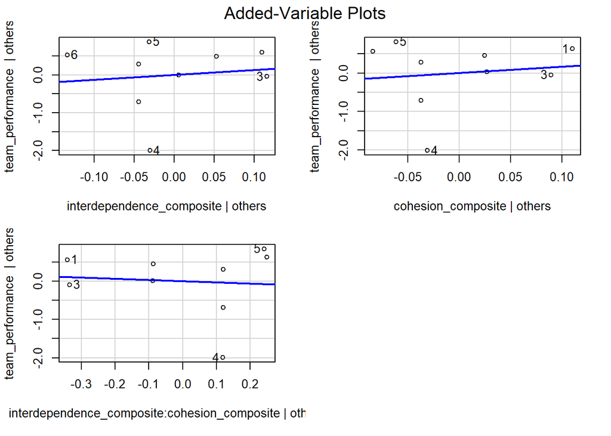

### Reflection

In order to examine the statement “team cohesion should be positively linked to team performance only when task interdependence is high”, I decided to also visualize the linear relationship between the team performance (response variable, team cohesion, and task interdependence (explanatory variables) using only data with high task interdependence that are greater than or equal to 3. The bottom left graphs of both sets of regression plots measure the association between the predictor variables (task interdependence and cohesion) and the outcome variable (team performance). The plot using only high interdependence data shows a negative correlation between the outcome variable and predictor variables while the plot using all data shows a positive correlation. These two plots does not support the above statement (probably because the data are randomly generated).

A concern I have for this analysis is that team performance is not only dependent on team cohesion and task dependency. Predicting a team’s performance solely based off of those two factors does not accurately reflect on a real-world scenario. I am also concerned with how the data was collected. How were the teams’ cohesion, task interdependence, and performance evaluated? Did the team members evaluate their teamwork themselves, or was it the researchers? If the researchers evaluated the teams, what was the standards/rubric used to measure a team’s cohesion, task interdependence, and performance?